# Covid-19 Summary for Hartford County

2021-04-24

This table summarizes trends in each town in Hartford County. It is sorted by the category of town as developed in the report [The Five Connecticuts](https://ctdatahaven.org/sites/ctdatahaven/files/UConnCPR%20Changing%20Demographics-5%20CTs%202004.pdf): Urban Core, Urban Periphery, Wealthy, Suburban, and Rural.

For each town it shows the category, the population, the total number of cases to date, the number of recent cases per 100K of population (new cases in the last two weeks), total deaths, and the percentage of total deaths in that town attributed to nursing home residents.

The purpose of this table is to make it easier to quickly scan for trends in local towns.

The town sparklines at the right show the trends over time. The vertical scale is different for new cases and for deaths. For new cases, the maximum height shown on the scale is 100 while for deaths, the maximum value shown is 23.7. For both new cases and deaths, the sparkline shows the rolling seven day average of new cases or deaths.

| town | category | total population | total cases | recent cases per 100K | total deaths | % deaths from nursing homes | town cases | town deaths |
| --- | --- | --- | --- | --- | --- | --- | --- | --- |
| Hartford | Urban Core | 123,628 | 15,527 | 397.2 | 288 | 42% |  |  |
| New Britain | Urban Core | 72,839 | 9,224 | 436.6 | 205 | 72% |  |  |
| Bloomfield | Urban Periphery | 20,952 | 1,968 | 286.4 | 107 | 69% |  |  |
| Bristol | Urban Periphery | 60,308 | 5,762 | 490.8 | 133 | 86% |  |  |
| East Hartford | Urban Periphery | 50,453 | 6,167 | 376.6 | 149 | 68% |  |  |
| Enfield | Urban Periphery | 44,455 | 3,469 | 348.7 | 53 | 86% |  |  |
| Manchester | Urban Periphery | 57,955 | 4,655 | 248.5 | 148 | 79% |  |  |
| Newington | Urban Periphery | 30,323 | 2,655 | 217.7 | 101 | 72% |  |  |
| Plainville | Urban Periphery | 17,720 | 1,508 | 293.5 | 37 | 68% |  |  |
| Rocky Hill | Urban Periphery | 20,137 | 1,747 | 367.5 | 122 | 70% |  |  |
| West Hartford | Urban Periphery | 63,127 | 4,487 | 240.8 | 229 | 79% |  |  |
| Wethersfield | Urban Periphery | 26,267 | 2,468 | 175.1 | 37 | NA |  |  |
| Windsor Locks | Urban Periphery | 12,613 | 1,025 | 229.9 | 31 | 68% |  |  |
| Avon | Suburban | 18,338 | 954 | 250.8 | 75 | 78% |  |  |
| Berlin | Suburban | 20,519 | 1,525 | 224.2 | 31 | 38% |  |  |
| Burlington | Suburban | 9,607 | 578 | 239.4 | 5 | NA |  |  |
| East Granby | Suburban | 5,256 | 277 | 247.3 | 3 | NA |  |  |
| Farmington | Suburban | 25,546 | 1,462 | 199.6 | 46 | 62% |  |  |
| Glastonbury | Suburban | 34,578 | 2,138 | 188.0 | 105 | 62% |  |  |
| Granby | Suburban | 11,305 | 576 | 159.2 | 30 | NA |  |  |
| Marlborough | Suburban | 6,394 | 398 | 359.7 | 23 | 92% |  |  |
| Simsbury | Suburban | 24,519 | 1,061 | 146.8 | 25 | 55% |  |  |
| South Windsor | Suburban | 25,823 | 1,596 | 220.7 | 52 | NA |  |  |
| Southington | Suburban | 43,763 | 3,568 | 356.5 | 94 | 84% |  |  |
| Suffield | Suburban | 15,662 | 1,548 | 268.2 | 34 | 95% |  |  |
| Windsor | Suburban | 28,917 | 2,738 | 266.3 | 133 | 85% |  |  |
| Canton | Rural | 10,306 | 485 | 203.8 | 37 | 86% |  |  |
| East Windsor | Rural | 11,379 | 906 | 219.7 | 46 | 88% |  |  |
| Hartland | Rural | 2,041 | 91 | 98.0 | 2 | NA |  |  |

The first map shows cases by town in Hartford County. The second map shows the percentage of individuals below the poverty line.

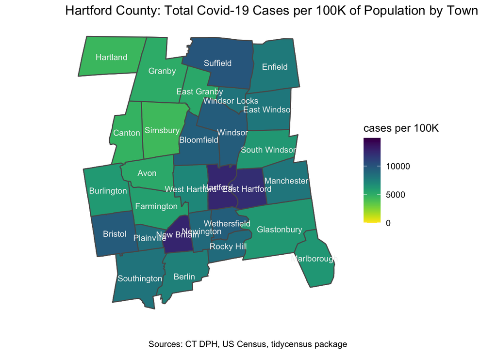

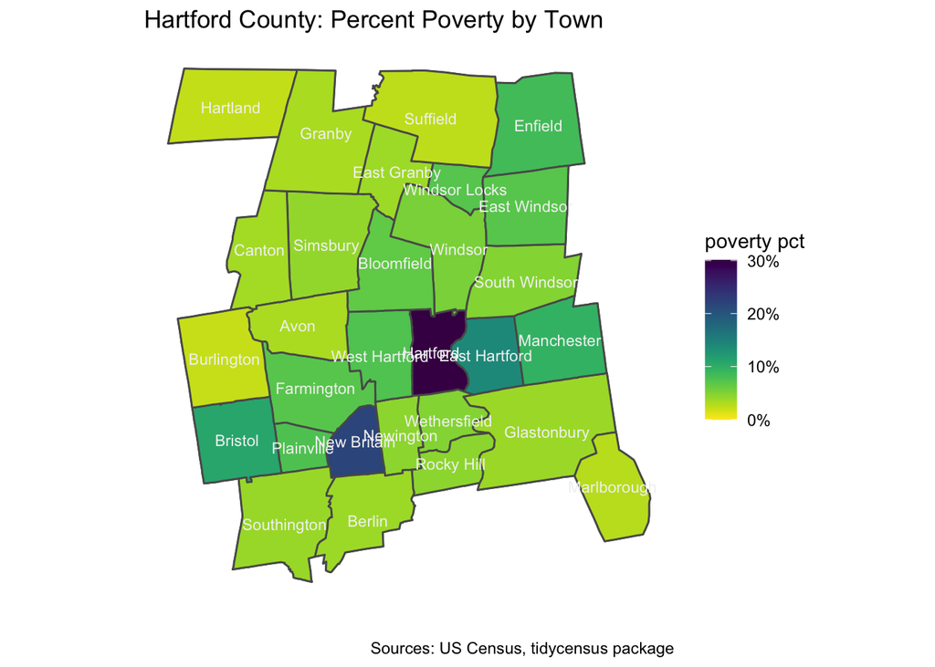